# POL40950: Introduction to Statistics

Homework 1

Nilesh Nayak

Deadline: 7 October 2021

## Instructions

- Rename this file to your LASTNAME_FIRSTNAME_homework01.Rmd and insert your name at the header of this script (see `INSERT YOUR NAME`).
- If an answer to a question requires code, add the code in the code block below. For questions that need interpretations or explanations, write your answer in *italics* (using `_` and `_` at the beginning and end of your answer) below the question.
- **This script will only knit if `data_which_candidate.rds` and `dat_elections.csv` are stored in the same folder as this RMarkdown file! Both datasets are in the “Homeworks” folder on Brightspace.**
- Please knit this file as an .html document and upload the .html document to the assignment folder on Brightspace.
- If the code for one of the questions is not working, leave the code in the chunk, but change the beginning of the chunk to `{r,eval=FALSE}`. Only do this as a last resort, though.

install.packages(“dplyr”)

```r
# load required package
library(tidyverse)
library(dplyr)
library(ggplot2)
```

## Working with and Wrangling Survey Data (100 points + 5 bonus points)

In this homework, we work with responses to the Voting Advice Application “Which Candidate”. You can see the raw data at: https://doi.org/10.7910/DVN/OEYRN7.

We use a cleaned version of the original file. Let’s load the file:

```r
# make sure to store the datsets in the same folder as this .Rmd file!
dat_vaa <- readRDS("data_which_candidate.rds")
```

1. How many observations does the dataset consist of? What is the unit of analysis? And which variables are included in this dataset (check out `names()`)? [5 points]

```r
dim(dat_vaa)
```

```
## [1] 141936      4
```

*There are 141936 observations and 4 variables before removing missing values*

```r
head(dat_vaa,10)
```

```
## # A tibble: 10 x 4
## # Groups:   partyvote [5]
##    immig partyvote        lr_selfplacement age
##    <dbl> <chr>                       <dbl> <fct>
##  1    NA <NA>                           NA <NA>
##  2    NA <NA>                           NA <NA>
##  3    NA <NA>                           NA <NA>
##  4     0 Social Democrats                2 18-24
##  5     0 <NA>                           NA <NA>
##  6     0 <NA>                           NA <NA>
##  7     1 <NA>                            3 25-34
##  8     1 Fianna Fáil                     2 25-34
##  9     0 Fine Gael                       4 35-44
## 10    NA Green Party                     5 35-44
```

```r
summary(dat_vaa)
```

```
##      immig        partyvote         lr_selfplacement      age
##  Min.   :0.000   Length:141936      Min.   : 0.00    25-34  :30080
##  1st Qu.:0.000   Class :character   1st Qu.: 3.00    35-44  :22187
##  Median :0.000   Mode  :character   Median : 4.00    18-24  :19227
##  Mean   :0.272                      Mean   : 3.92    45-54  : 9573
##  3rd Qu.:1.000                      3rd Qu.: 5.00    55-65  : 4975
##  Max.   :1.000                      Max.   :10.00    (Other): 1967
##  NA's   :28892                      NA's   :61591    NA's   :53927
```

```r
names(dat_vaa)
```

```
## [1] "immig"            "partyvote"        "lr_selfplacement" "age"
```

*There are 4 variables in the dataset : immig, partyvote, lr_selfplacement, age*

```r
dat_vaa_filtered = dat_vaa %>% drop_na()
dim(dat_vaa_filtered)
```

```
## [1] 45880     4
```

*There are 45880 observations and 4 variables after removing missing values*

```r
summary(dat_vaa_filtered)
```

```
##      immig         partyvote         lr_selfplacement       age
##  Min.   :0.0000   Length:45880       Min.   : 0.000   under 18:    0
##  1st Qu.:0.0000   Class :character   1st Qu.: 2.000   18-24   : 9547
##  Median :0.0000   Mode  :character   Median : 4.000   25-34   :15214
##  Mean   :0.2407                      Mean   : 3.753   35-44   :11696
##  3rd Qu.:0.0000                      3rd Qu.: 5.000   45-54   : 5319
##  Max.   :1.0000                      Max.   :10.000   55-65   : 2899
##                                                       over 65 : 1205
```

```r
head(dat_vaa_filtered,10)
```

```
## # A tibble: 10 x 4
## # Groups:   partyvote [5]
##    immig partyvote        lr_selfplacement age
##    <dbl> <chr>                       <dbl> <fct>
##  1     0 Social Democrats                2 18-24
##  2     1 Fianna Fáil                     2 25-34
##  3     0 Fine Gael                       4 35-44
##  4     0 Green Party                     3 18-24
##  5     0 S-PBP                           0 18-24
##  6     0 Social Democrats                3 55-65
##  7     0 S-PBP                           1 18-24
##  8     0 Green Party                     2 18-24
##  9     0 Green Party                     2 35-44
## 10     0 Green Party                     3 25-34
```

*Unit of analysis is -> Party vote share per age group at each country level which support more/less restrictive immigration policies*

2. Group the data frame by `partyvote` (check `group_by()`) and get the absolute frequency (`count()`) of respondents per party. [5 points]

```r
dat_vaa_group_partyvote_count <- dat_vaa_filtered %>% group_by(partyvote) %>% count()
names(dat_vaa_group_partyvote_count)[2] <- "count"
dat_vaa_group_partyvote_count
```

```
## # A tibble: 9 x 2
## # Groups:   partyvote [9]
##   partyvote        count
##   <chr>            <int>
## 1 Aontú              424
## 2 Fianna Fáil       5169
## 3 Fine Gael         6647
## 4 Green Party      10514
## 5 Labour            2994
## 6 Other/Ind         4175
## 7 S-PBP             2489
## 8 Sinn Féin         8577
## 9 Social Democrats  4891
```

3. Calculate the relative frequencies of respondents (=proportions) in each `partyvote` group. Note: you will find suggestions on how to calculate proportions per group online at StackOverFlow. [10 points]

```r
dat_vaa_group_partyvote_freq = dat_vaa_filtered %>%  group_by(partyvote) %>% summarise(count = n()) %>%   mutate(relative_frequency = round(count / sum(count), 3)*100) %>%
  arrange(desc(relative_frequency))

dat_vaa_group_partyvote_freq
```

```
## # A tibble: 9 x 3
##   partyvote        count relative_frequency
##   <chr>            <int>              <dbl>
## 1 Green Party      10514               22.9
## 2 Sinn Féin         8577               18.7
## 3 Fine Gael         6647               14.5
## 4 Fianna Fáil       5169               11.3
## 5 Social Democrats  4891               10.7
## 6 Other/Ind         4175                9.1
## 7 Labour            2994                6.5
## 8 S-PBP             2489                5.4
## 9 Aontú              424                0.9
```

4. Get the first-preference vote shares for Irish parties in 2020 from the ParlGov dataset (`dat_elections`). Are voters from certain parties over- or under-represented in the Voting Advice Application data compared with the official election results? Is this dataset representative of Irish voters? [15 points]

```r
# load ParlGov election data
# removed fileEncoding = "UTF-8"
#dat_elections <- read.csv("dat_elections.csv",fileEncoding = "UTF-8")

dat_elections <- read.csv("https://parlgov.org/data/parlgov-development_csv-utf-8/view_election.csv")
dim(dat_elections)
```

```
## [1] 8673   16
```

```r
dat_elections = dat_elections %>% drop_na()
dim(dat_elections)
```

```
## [1] 7159   16
```

```r
head(dat_elections)
```

```
##   country_name_short country_name election_type election_date vote_share seats
## 1                AUS    Australia    parliament    1903-12-16       29.7    26
## 2                AUS    Australia    parliament    1903-12-16       34.4    25
## 3                AUS    Australia    parliament    1903-12-16       31.0    23
## 4                AUS    Australia    parliament    1906-12-02       38.2    27
## 5                AUS    Australia    parliament    1906-12-02       36.6    26
## 6                AUS    Australia    parliament    1906-12-02       16.4    16
##   seats_total party_name_short             party_name     party_name_english
## 1          75               PP    Protectionist Party    Protectionist Party
## 2          75              FTP       Free Trade Party       Free Trade Party
## 3          75              ALP Australian Labor Party Australian Labor Party
## 4          75              FTP       Free Trade Party       Free Trade Party
## 5          75              ALP Australian Labor Party Australian Labor Party
## 6          75               PP    Protectionist Party    Protectionist Party
##   left_right country_id election_id previous_parliament_election_id
## 1     7.4000         33         730                             731
## 2     6.0000         33         730                             731
## 3     3.8833         33         730                             731
## 4     6.0000         33         725                             730
## 5     3.8833         33         725                             730
## 6     7.4000         33         725                             730
##   previous_cabinet_id party_id
## 1                 997     1898
## 2                 997     1938
## 3                 997     1253
## 4                1000     1938
## 5                1000     1253
## 6                1000     1898
```

```r
newdata <- subset(dat_elections, country_name=="Ireland" & substr(election_date,1,4)=="2020")
dim(newdata)
```

```
## [1]  9 16
```

```r
newdata
```

```
##      country_name_short country_name election_type election_date vote_share
## 4105                IRL      Ireland    parliament    2020-02-08      22.18
## 4106                IRL      Ireland    parliament    2020-02-08      24.53
## 4107                IRL      Ireland    parliament    2020-02-08      20.86
## 4108                IRL      Ireland    parliament    2020-02-08       7.13
## 4109                IRL      Ireland    parliament    2020-02-08       4.38
## 4110                IRL      Ireland    parliament    2020-02-08       2.90
## 4111                IRL      Ireland    parliament    2020-02-08       2.63
## 4112                IRL      Ireland    parliament    2020-02-08       1.90
## 4113                IRL      Ireland    parliament    2020-02-08       0.39
##      seats seats_total party_name_short
## 4105    38         160               FF
## 4106    37         160               SF
## 4107    35         160               FG
## 4108    12         160            Green
```

[output cut: 35 more lines]

```r
newdata %>% select(party_name_english, vote_share)
```

```
##                      party_name_english vote_share
## 4105                        Fianna Fail      22.18
## 4106                          Sinn Fein      24.53
## 4107   Fine Gael (Familiy of the Irish)      20.86
## 4108                        Green Party       7.13
## 4109                       Labour Party       4.38
## 4110                  Social Democrats        2.90
## 4111 Solidarity -- People Before Profit       2.63
## 4112                              Aontu       1.90
## 4113              Independents 4 Change       0.39
```

```r
cbind(newdata %>% select(party_name_english, vote_share), partyvote = dat_vaa_group_partyvote_freq$partyvote, relative_frequency = dat_vaa_group_partyvote_freq$relative_frequency)
```

```
##                      party_name_english vote_share        partyvote
## 4105                        Fianna Fail      22.18      Green Party
## 4106                          Sinn Fein      24.53        Sinn Féin
## 4107   Fine Gael (Familiy of the Irish)      20.86        Fine Gael
## 4108                        Green Party       7.13      Fianna Fáil
## 4109                       Labour Party       4.38 Social Democrats
## 4110                  Social Democrats        2.90        Other/Ind
## 4111 Solidarity -- People Before Profit       2.63           Labour
## 4112                              Aontu       1.90            S-PBP
## 4113              Independents 4 Change       0.39            Aontú
##      relative_frequency
## 4105               22.9
## 4106               18.7
## 4107               14.5
## 4108               11.3
## 4109               10.7
## 4110                9.1
## 4111                6.5
## 4112                5.4
## 4113                0.9
```

*Green Party and Social Democrats are over represented as survey respondents are very high, but vote share received is lesser.*

*Fianna Fail , Fine Gael, Sinn Fein are under represented as survey respondents are lower, but vote share received is higher.*

5. The variable `immig` takes the value 1 if a respondent expressed that immigration “should be more restrictive”. (The original question is: “Should immigration into Ireland be made more restrictive or less restrictive?”). What proportion of *all* participants agrees that immigration should be more restrictive? [5 points]

```r
dat_vaa %>%  group_by(immig) %>% summarise(cnt = n()) %>% mutate(freq = round(cnt / sum(cnt)*100, 3)) %>%  arrange(desc(freq))
```

```
## # A tibble: 3 x 3
##   immig   cnt  freq
##   <dbl> <int> <dbl>
## 1     0 82252  58.0
## 2     1 30792  21.7
## 3    NA 28892  20.4
```

*21.69% agree that immigration should be more restrictive*

*I have considered the “dat_vaa” dataframe which has NA’s. I think the NA’s add the impact in the “all participants list” since these respondents could voluntarily chose to not provide an input in the survey*

6. Calculate these proportions separately for supporters from each party (using `partyvote` as the grouping variable). [5 points]

```r
dat_vaa_filtered %>%  group_by(partyvote, immig) %>%  summarise(cnt = n()) %>% mutate(freq = round(cnt / sum(cnt)*100, 3)) %>%  arrange(partyvote, immig)
```

```
## # A tibble: 18 x 4
## # Groups:   partyvote [9]
##    partyvote        immig   cnt  freq
##    <chr>            <dbl> <int> <dbl>
##  1 Aontú                0   209 49.3
##  2 Aontú                1   215 50.7
##  3 Fianna Fáil          0  3162 61.2
##  4 Fianna Fáil          1  2007 38.8
##  5 Fine Gael            0  4888 73.5
##  6 Fine Gael            1  1759 26.5
##  7 Green Party          0  9739 92.6
##  8 Green Party          1   775  7.37
##  9 Labour               0  2469 82.5
## 10 Labour               1   525 17.5
## 11 Other/Ind            0  2532 60.6
## 12 Other/Ind            1  1643 39.4
## 13 S-PBP                0  2177 87.5
## 14 S-PBP                1   312 12.5
## 15 Sinn Féin            0  5367 62.6
## 16 Sinn Féin            1  3210 37.4
## 17 Social Democrats     0  4295 87.8
## 18 Social Democrats     1   596 12.2
```

*I have considered the “dat_vaa_filtered” dataframe initially since each party would specifically want to understand immig = 1 versus immig = 0 excluding the NA’s to make a decision*

7. Create a barplot with the `partyvote` on the x-axis and the proportion of respondents who favour more restrictive immigration policies on the y-axis. [5 points]

```r
data_immig = dat_vaa_filtered %>%  group_by(partyvote, immig) %>%  summarise(cnt = n()) %>% mutate(freq = round(cnt / sum(cnt)*100, 3))
data_immig
```

```
## # A tibble: 18 x 4
## # Groups:   partyvote [9]
##    partyvote        immig   cnt  freq
##    <chr>            <dbl> <int> <dbl>
##  1 Aontú                0   209 49.3
##  2 Aontú                1   215 50.7
##  3 Fianna Fáil          0  3162 61.2
##  4 Fianna Fáil          1  2007 38.8
##  5 Fine Gael            0  4888 73.5
##  6 Fine Gael            1  1759 26.5
##  7 Green Party          0  9739 92.6
##  8 Green Party          1   775  7.37
##  9 Labour               0  2469 82.5
## 10 Labour               1   525 17.5
## 11 Other/Ind            0  2532 60.6
## 12 Other/Ind            1  1643 39.4
## 13 S-PBP                0  2177 87.5
## 14 S-PBP                1   312 12.5
## 15 Sinn Féin            0  5367 62.6
## 16 Sinn Féin            1  3210 37.4
## 17 Social Democrats     0  4295 87.8
## 18 Social Democrats     1   596 12.2
```

```r
data_immig1 = subset(data_immig, data_immig$immig == '1')
data_immig1
```

```
## # A tibble: 9 x 4
## # Groups:   partyvote [9]
##   partyvote        immig   cnt  freq
##   <chr>            <dbl> <int> <dbl>
## 1 Aontú                1   215 50.7
## 2 Fianna Fáil          1  2007 38.8
## 3 Fine Gael            1  1759 26.5
## 4 Green Party          1   775  7.37
## 5 Labour               1   525 17.5
## 6 Other/Ind            1  1643 39.4
## 7 S-PBP                1   312 12.5
## 8 Sinn Féin            1  3210 37.4
## 9 Social Democrats     1   596 12.2
```

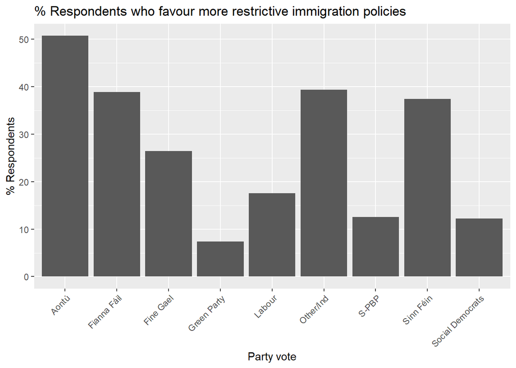

```r
data_immig1 %>% ggplot(aes(x = partyvote, y = freq)) + geom_col()+
  theme(axis.text.x = element_text(angle = 45, hjust=1)) + labs(x = "Party vote", y = "% Respondents", title = "% Respondents who favour more restrictive immigration policies")
```

8. Reorder the parties on the x-axis in descending order (the party with the highest proportions should be the first party in the graph). [5 points]

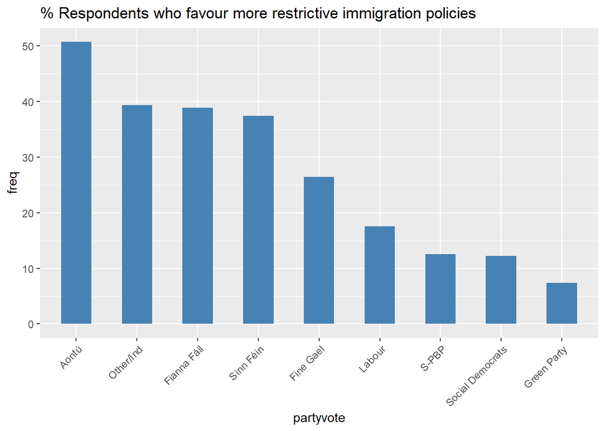

```r
data_immig1$partyvote = factor(data_immig1$partyvote, levels = data_immig1$partyvote[order(data_immig1$freq, decreasing = TRUE)])

data_immig1 %>% ggplot(aes(x = partyvote, y = freq)) + geom_col(fill="steelblue", width=0.5)+
  theme(axis.text.x = element_text(angle = 45, hjust=1)) + labs(title="% Respondents who favour more restrictive immigration policies")
```

*Aontú has highest respondents who favour more restrictions*

9. Use `coord_flip()` to flip the x- and y-axes. Create nicer axis labels and use `theme_bw()` to change the theme to a black-and-white theme. [5 points]

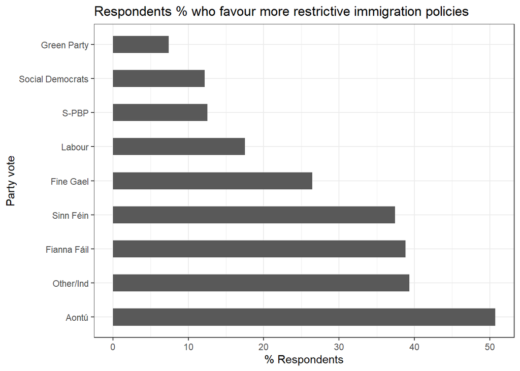

```r
#how to use x label and y label and give it colours
data_immig1 %>% ggplot(aes(x = partyvote, y = freq)) + geom_col(width=0.5)+ coord_flip() + theme_bw() + labs(x = "Party vote", y = "% Respondents", title = "Respondents % who favour more restrictive immigration policies")
```

10. Now we turn to left-right positions. The variable `lr_selfplacement` measures the left-right position of a respondent. How many respondents did *not* specify their left-right self-placement? [5 points]

```r
sum(is.na(dat_vaa$lr_selfplacement))
```

```
## [1] 61591
```

*61591 respondents did not specify their left-right self-placement* *I have considered the original dataframe “dat_vaa” containing all NA values*

11. Create a histogram of left-right positions with “small multiples” for each group of party supporters (check out `facet_wrap()`)? [5 points]

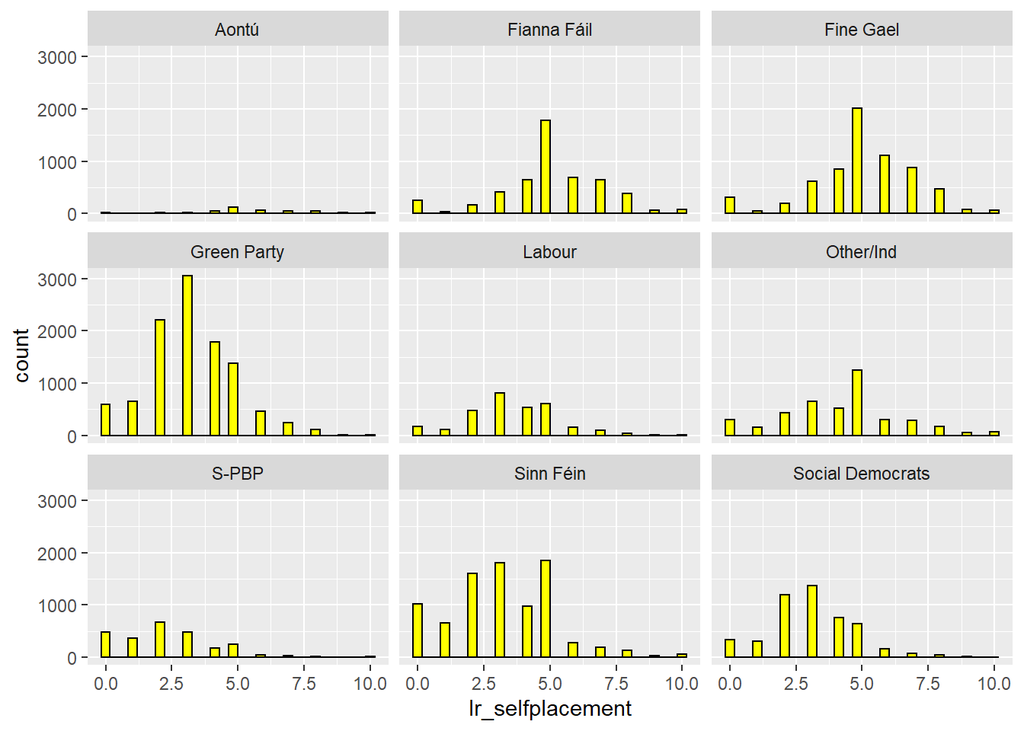

```r
#Need to do facetwrap
ggplot(dat_vaa_filtered, aes(x=lr_selfplacement), main="Histogram for left-right positions", xlab="LR positions", ylab='count')+ geom_histogram(color="black", fill="yellow")+ facet_wrap(partyvote ~ .)
```

12. Use `summarise()` to calculate the
- average left-right position
- median left-right position
- standard deviation of the left-right position

and store this data frame as a new object (always exclude missing responses). [5 points]

```r
summarised_object = dat_vaa %>% summarise(mean = mean(lr_selfplacement, na.rm = TRUE), median = median(lr_selfplacement, na.rm = TRUE), std_dev = sd(lr_selfplacement, na.rm = TRUE))
summarised_object
```

```
## # A tibble: 10 x 4
##    partyvote         mean median std_dev
##    <chr>            <dbl>  <dbl>   <dbl>
##  1 Aontú             5.35      5    2.14
##  2 Fianna Fáil       5.09      5    1.99
##  3 Fine Gael         5.10      5    1.97
##  4 Green Party       3.31      3    1.70
##  5 Labour            3.66      4    1.75
##  6 Other/Ind         4.28      5    2.14
##  7 S-PBP             2.40      2    1.80
##  8 Sinn Féin         3.27      3    2.02
##  9 Social Democrats  3.14      3    1.67
## 10 <NA>              4.07      4    1.94
```

*I have considered the dataframe with NA initially and removed the NA’s at column level for the calculation purpose*

13. Repeat the step above, but first group the data frame by `partyvote` and then get the average, median, and standard deviation separately for supporters from each party. [5 points]

```r
mean = dat_vaa %>%  group_by(partyvote) %>% summarise(mean_lr_replacement = mean(lr_selfplacement, na.rm = TRUE))
mean
```

```
## # A tibble: 10 x 2
##    partyvote        mean_lr_replacement
##    <chr>                          <dbl>
##  1 Aontú                           5.35
##  2 Fianna Fáil                     5.09
##  3 Fine Gael                       5.10
##  4 Green Party                     3.31
##  5 Labour                          3.66
##  6 Other/Ind                       4.28
##  7 S-PBP                           2.40
##  8 Sinn Féin                       3.27
##  9 Social Democrats                3.14
## 10 <NA>                            4.07
```

```r
med = dat_vaa %>%  group_by(partyvote) %>% summarise(median_lr_replacement = median(lr_selfplacement, na.rm = TRUE))
med
```

```
## # A tibble: 10 x 2
##    partyvote        median_lr_replacement
##    <chr>                            <dbl>
##  1 Aontú                                5
##  2 Fianna Fáil                          5
##  3 Fine Gael                            5
##  4 Green Party                          3
##  5 Labour                               4
##  6 Other/Ind                            5
##  7 S-PBP                                2
##  8 Sinn Féin                            3
##  9 Social Democrats                     3
## 10 <NA>                                 4
```

```r
sd = dat_vaa %>%  group_by(partyvote) %>% summarise(sd_lr_replacement = sd(lr_selfplacement, na.rm = TRUE))
sd
```

```
## # A tibble: 10 x 2
##    partyvote        sd_lr_replacement
##    <chr>                        <dbl>
##  1 Aontú                         2.14
##  2 Fianna Fáil                   1.99
##  3 Fine Gael                     1.97
##  4 Green Party                   1.70
##  5 Labour                        1.75
##  6 Other/Ind                     2.14
##  7 S-PBP                         1.80
##  8 Sinn Féin                     2.02
##  9 Social Democrats              1.67
## 10 <NA>                          1.94
```

```r
new_object = data.frame(merge(merge(mean,med, by.x = "partyvote", by.y = "partyvote"), sd, by.x = "partyvote", by.y = "partyvote"))
new_object
```

```
##           partyvote mean_lr_replacement median_lr_replacement sd_lr_replacement
## 1             Aontú            5.347059                     5          2.144839
## 2       Fianna Fáil            5.086515                     5          1.990496
## 3         Fine Gael            5.099989                     5          1.968478
## 4       Green Party            3.313337                     3          1.697322
## 5            Labour            3.659694                     4          1.754298
## 6         Other/Ind            4.275785                     5          2.142248
## 7             S-PBP            2.396239                     2          1.804933
## 8         Sinn Féin            3.272919                     3          2.017916
## 9  Social Democrats            3.143819                     3          1.665479
## 10             <NA>            4.067062                     4          1.942032
```

*I have explored the 3 results using Merge function using column ‘partyvote’ to ensure 1:1 mapping and then stored into object as a data frame*

14. Interpret the output: voters from which party are - on average - the most “left”, and voters from which party are - on average - most “right”? For which party do we observe the largest standard deviation, and what does a larger standard deviation imply regarding the distribution of left-right self-placements? [5 points]

*Voters from Aontú are the most right with largest average 5.34 and voters from S-PBP are most left with smallest average 2.39* *Aontú has largest standard deviation 2.14* *Larger standard deviation imply data is largely spreadout and its distance from mean left-right self-placements is higher than the rest*

15. Group the data frame by `immig` and get the average left-right position for the two groups. Which group has a higher average left-right value? [5 points]

```r
dat_vaa_filtered %>%  group_by(immig) %>% summarise(mean_lr_selfplacement = mean(lr_selfplacement, na.rm = TRUE))
```

```
## # A tibble: 2 x 2
##   immig mean_lr_selfplacement
##   <dbl>                 <dbl>
## 1     0                  3.46
## 2     1                  4.68
```

*The group with immig = 1 (support more restrictive policies) has higher average left-right value*

16. We now use a categorical variable `age`. Use `count()` to get the distribution of age groups (using absolute frequencies/counts). Which age category is the modal age category? [5 points]

```r
dat_vaa_filtered %>%  group_by(age) %>% summarise(cnt = n()) %>%
  mutate(freq = round(cnt / sum(cnt)*100, 3)) %>%  arrange(desc(freq))
```

```
## # A tibble: 6 x 3
##   age       cnt  freq
##   <fct>   <int> <dbl>
## 1 25-34   15214 33.2
## 2 35-44   11696 25.5
## 3 18-24    9547 20.8
## 4 45-54    5319 11.6
## 5 55-65    2899  6.32
## 6 over 65  1205  2.63
```

*25-34 is the modal age category with highest count*

17. Create a new binary variable that distinguishes between respondents who would vote for Sinn Féin and all other respondents. You can use `ifelse()` to recode a variable into two categories. You can name this variable `sinn_fein_binary`. [5 points]

```r
head(dat_vaa_filtered,6)
```

```
## # A tibble: 6 x 4
## # Groups:   partyvote [5]
##   immig partyvote        lr_selfplacement age
##   <dbl> <chr>                       <dbl> <fct>
## 1     0 Social Democrats                2 18-24
## 2     1 Fianna Fáil                     2 25-34
## 3     0 Fine Gael                       4 35-44
## 4     0 Green Party                     3 18-24
## 5     0 S-PBP                           0 18-24
## 6     0 Social Democrats                3 55-65
```

```r
w <- function(x) return(ifelse(x == "Sinn Féin", 'yes' , 'no'))
#head(w(dat_elections$party_name))

#creating the binary variable sinn_fein_binary with values 'yes' or 'no'
dat_sinn_fein_binary <- dat_vaa %>% mutate(sinn_fein_binary = w(partyvote))
head(dat_sinn_fein_binary,20)
```

```
## # A tibble: 20 x 5
## # Groups:   partyvote [7]
##    immig partyvote        lr_selfplacement age   sinn_fein_binary
##    <dbl> <chr>                       <dbl> <fct> <chr>
##  1    NA <NA>                           NA <NA>  <NA>
##  2    NA <NA>                           NA <NA>  <NA>
##  3    NA <NA>                           NA <NA>  <NA>
##  4     0 Social Democrats                2 18-24 no
##  5     0 <NA>                           NA <NA>  <NA>
##  6     0 <NA>                           NA <NA>  <NA>
##  7     1 <NA>                            3 25-34 <NA>
##  8     1 Fianna Fáil                     2 25-34 no
##  9     0 Fine Gael                       4 35-44 no
## 10    NA Green Party                     5 35-44 no
## 11     0 Labour                          1 <NA>  no
## 12     0 <NA>                           NA <NA>  <NA>
## 13    NA <NA>                            5 18-24 <NA>
## 14    NA <NA>                            6 35-44 <NA>
## 15     0 <NA>                           NA <NA>  <NA>
## 16     0 Green Party                     3 18-24 no
## 17     0 S-PBP                           0 18-24 no
## 18     0 <NA>                           NA <NA>  <NA>
## 19     0 Social Democrats                3 55-65 no
## 20     0 <NA>                           NA <NA>  <NA>
```

```r
#checking if we have rows with sinn_fein_binary == "yes" and "no"
filter(dat_sinn_fein_binary, partyvote != "Sinn Féin")
```

```
## # A tibble: 51,015 x 5
## # Groups:   partyvote [8]
##    immig partyvote        lr_selfplacement age   sinn_fein_binary
##    <dbl> <chr>                       <dbl> <fct> <chr>
##  1     0 Social Democrats                2 18-24 no
##  2     1 Fianna Fáil                     2 25-34 no
##  3     0 Fine Gael                       4 35-44 no
##  4    NA Green Party                     5 35-44 no
##  5     0 Labour                          1 <NA>  no
##  6     0 Green Party                     3 18-24 no
##  7     0 S-PBP                           0 18-24 no
##  8     0 Social Democrats                3 55-65 no
##  9     0 S-PBP                           1 18-24 no
## 10     0 Green Party                     2 18-24 no
## # ... with 51,005 more rows
```

```r
filter(dat_sinn_fein_binary, partyvote == "Sinn Féin")
```

```
## # A tibble: 12,132 x 5
## # Groups:   partyvote [1]
##    immig partyvote lr_selfplacement age   sinn_fein_binary
##    <dbl> <chr>                <dbl> <fct> <chr>
##  1    NA Sinn Féin                5 35-44 yes
##  2     0 Sinn Féin                2 25-34 yes
##  3     0 Sinn Féin                1 18-24 yes
##  4     0 Sinn Féin                4 18-24 yes
##  5    NA Sinn Féin                2 18-24 yes
##  6     0 Sinn Féin                2 25-34 yes
##  7     0 Sinn Féin                2 18-24 yes
##  8     0 Sinn Féin               NA 25-34 yes
##  9     0 Sinn Féin                2 25-34 yes
## 10     1 Sinn Féin               NA 25-34 yes
## # ... with 12,122 more rows
```

```r
table(dat_sinn_fein_binary$sinn_fein_binary)
```

```
##
##    no   yes
## 51015 12132
```

18. **BONUS POINTS**: Create a barplot (`geom_bar()`) and plot the distribution of age groups for both groups of voters. Use `facet_wrap()` to create a plot with two “small multiples”. Are respondents who would vote for Sinn Féin younger than respondents who expressed a different vote choice? [5 points]

```r
dim(dat_sinn_fein_binary)
```

```
## [1] 141936      5
```

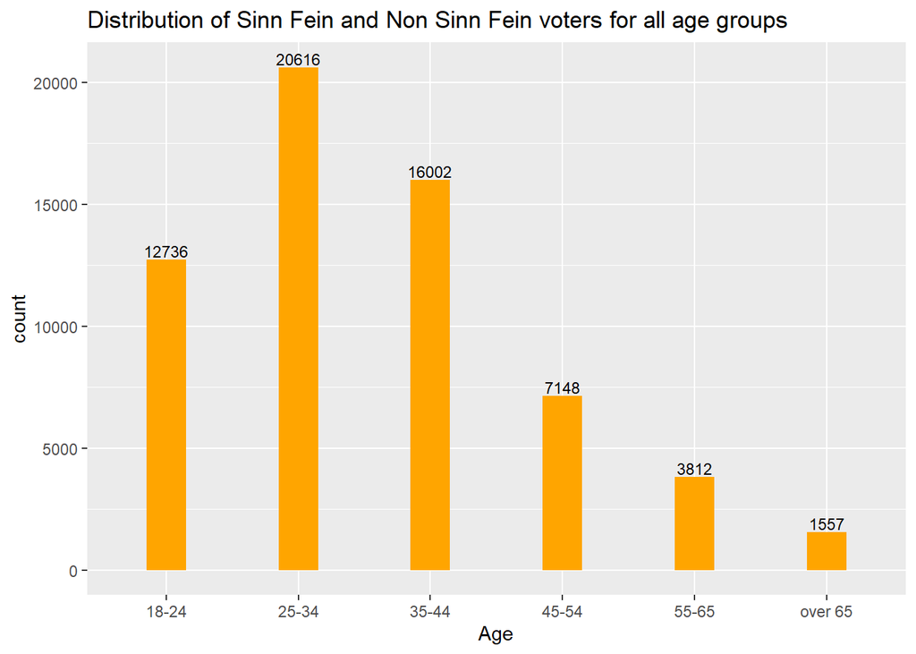

```r
#Bar graph
ggplot(filter(dat_sinn_fein_binary,!is.na(age)&!is.na(sinn_fein_binary)), aes(x = age)) + geom_bar(width = 0.3,  fill = 'orange') +  geom_text(aes(label = ..count..), stat = "count", colour = "black", vjust = -0.2, size = 3) + labs(x = "Age", y = "count", title = "Distribution of Sinn Fein and Non Sinn Fein voters for all age groups")
```

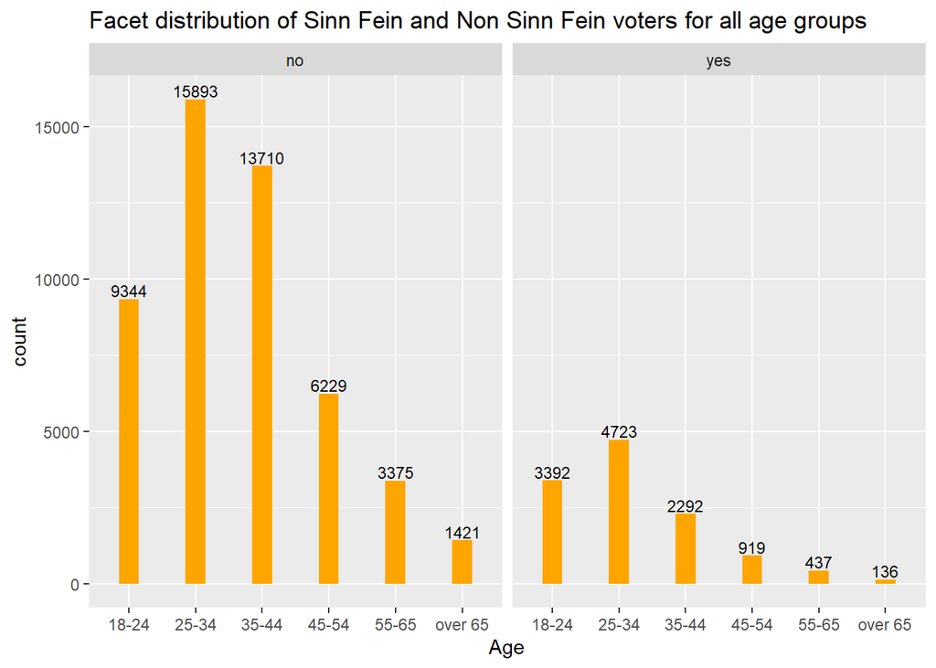

```r
#Graph with facet added
ggplot(filter(dat_sinn_fein_binary,!is.na(age)&!is.na(sinn_fein_binary)), aes(x = age)) + geom_bar(width = 0.3,  fill = 'orange') +   geom_text(aes(label = ..count..), stat = "count", colour = "black", vjust = -0.2, size = 3) + facet_wrap(~sinn_fein_binary) + labs(x = "Age", y = "count", title = "Facet distribution of Sinn Fein and Non Sinn Fein voters for all age groups")
```

*We cannot truly identify younger respondents as 18-24 or 25-34 or both of them combined* *If we are to assume younger respondents as 18-24, then we still do not know the individual ages of each respondents to come to a conclusion* *For example : 3392 can have 90% having age 24 and 10% between age 18-23. However, 9344 can have 5% with age 18-20 and 95% with age 21-24* *So there is no convincing answer to this question unless we know individual ages of all respondents*